# Collecting And Analyzing Twitter Data Using R

March 27th 2019,  
MZES Social Science Data Lab  
University of Mannheim

## About me

- Post-doc at Bielefeld University
- B.A. Sociology, M.A. Survey Methodology
- Dissertation on interviewer effects in f2f-surveys
- Research interests:
  - Survey methodology
  - Social inequality, discrimination
  - Social media and online data

https://www.simon-kuehne.de

## Workshop Agenda

- About Twitter
- The Twitter API
- Collecting Twitter data using R
- Analyzing Twitter data using R
- Give it a try on your own laptop!
- Potential issues & challenges
- Questions & Discussion

## Learning Goals

- Getting a better understanding of Twitter data, and thus, the potentials and limitations of using it in research projects
- Being able to collect Twitter data using R
- Being able to perform explorative analyses of the data using R

I will provide you with this presentation as well as R-Scripts that you can use to set up your own data collection and analysis.

## Questions? Anytime!

[figure not shown]

Also:

- I'm looking forward to any kind of feedback in order to improve this mini-workshop (as it is a premiere)
- Thanks!

## Twitter

[figure not shown]

- Online news and social networking service. Micro-blogging.
- Main function: Publicly sharing short texts/photos/links, "Tweets"
- About 326 Million monthly active users and 500 Million Tweets send each day (https://s22.q4cdn.com/826641620/files/doc_financials/2018/q3/TWTR-Q3_18_InvestorFactSheet.pdf)
- Germany:
  - No official numbers available
  - ARD/ZDF Online-Studie: 4% 1x week, 1% everyday (http://www.ard-zdf-onlinestudie.de/files/2018/0918_Frees_Koch.pdf)

## Twitter Mechanics

- Each user has a profile (page) and can add a photo and information about themselves
- Users can *follow* each other
- Users can *tweet*, i.e., publicly sharing a text/photo/link
- Each Tweet is restricted to a maximum of 280 characters
- Users can interact with a Tweet via *comments (replys), likes, shares (retweets)*
- Users can interact with other users via *direct messaging*
- Users can create a *thread* = A series of connected Tweets
- Users use *hashtags* (e.g., #mannheim) in order to associate their Tweets with certain topics and to make them easier to find
- Users can search for keywords/hashtags in order to find relevant Tweets and users

## Tweets

This is an example of a Tweet:

[figure not shown]

Let's have a look at Twitter: https://twitter.com/

## Why Do Many Social Scientists ❤️ Twitter?

- Analyzing Tweets and social interaction on Twitter can help to answer social science research questions, esp. in communication research and political science
- Contrary to Facebook and Instagram, Twitter data is (easily) accessible for researchers
  - Facebook: API shut-down in April 2018
  - Instagram: API shut-down in December 2018

## Twitter in Science

According to the Web of Science database (https://login.webofknowledge.com/), there are 2,598 journal articles published since 2009 with the word "Twitter" in their titles.

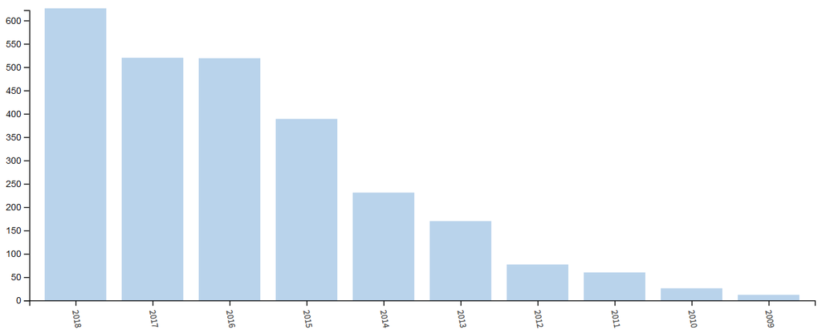

Source: Web of Science Search Tool, Journal Articles since 2009, "Twitter" in title.

## Twitter in Science

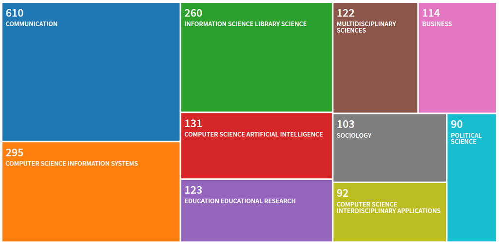

Source: Web of Science Search Tool, Journal Articles since 2009, "Twitter" in title.

## Collecting Twitter Data

[figure not shown]

Well, almost…

## The Twitter API Platform

- API = Application Programming Interface
- Allows to access (real-time) Twitter data, i.e., Tweets
- Twitter offers a variety of API services, some for free, others not (see https://developer.twitter.com/en/docs.html)
  - Search for Tweets published in the past
  - Stream Tweets in realtime
  - Manage Twitter accounts and ads
  - etc.
- Today, I will focus on the free of cost API service, that is used in the vast majority of research projects: **The Realtime Streaming API**

## The Streaming API - Collecting Tweets in Realtime

- https://developer.twitter.com/en/docs/tweets/filter-realtime/overview
- *"Establishing a connection to the streaming APIs means making a very long lived HTTP request, and parsing the response incrementally. Conceptually, you can think of it as downloading an infinitely long file over HTTP."*
- Receive up to a maximum of 1% of all Tweets worldwide
- As a query is usually specified by selected keywords or geographic areas, you will be able to collect (almost) all relevant Tweets
- There are three filter parameters that you can use:
  - 'Follow': Receive Tweets of up to 5,000 users
  - 'Track': Receive Tweets that contain up to 400 keywords
  - 'Location': Receive Tweets from within a set of up to 25 geographic bounding boxes

## API Authentification

You need to authenticate yourself when making requests to the Twitter API. Twitter uses the OAuth protocol, an *"open protocol to allow secure authorization in a simple and standard method from web, mobile and desktop applications."*, (see https://oauth.net/)

Necessary steps:

- Create a Twitter account
- Login to your Twitter account via https://developer.twitter.com/
- Create an app
- Create keys, access token & secret
- Use those to authenticate each query to the Twitter API

## How To Collect Twitter Data?

- There are a number of ways to collect Twitter data:
  - Write your own script to make continuous HTTP requests
  - Python: Package "tweepy"
  - R: Package "rtweet"
  - etc.
- In the following, I will show you how to collect Twitter data using different Streaming API endpoints and the "rtweet"-package
- https://rtweet.info/reference/stream_tweets.html

[figure not shown]

## What Do We Get From Twitter?

The Twitter API sends Tweets and related meta-information. These are stored in a .json format (Java Script Object Notation). Each object ('row') represents a Tweet or ReTweet and contains the following information:

- The content of a Tweet + Tweet-URL + Tweet-ID
- User-name + User-ID
- Time-stamp
- Place, country, geocodes (rarely)
- User self-description, residence, no. of followers, no. of friends
- URLs to images, videos
- etc.

## Collecting Tweets Using the rtweet-Package

See R-script "1_collect_tweets.R"

## Analyzing Twitter Data - Two Examples

See R-script "2_analyze_content.R" and R-project "3_analyze_locations.Rproj"

## Exercise - Collect Tweets on a Trending Topic

- Download R-Script "exercise_mzes_twitter_workshop.R" via https://github.com/SocialScienceDataLab/twitter
- Choose a trending topic (keyword), e.g., brexit, climate, article13, trump
- Modify the R-Script and collect Tweets in realtime
- Which words are used most often in the Tweets?

As you are all using a single test account and authentication tokens simultaneously, there may be some API rate limit issues. As mentioned above, you need to create your own Twitter account, app and authentication keys for your future data collection projects.

## Analyzing Twitter Data - Some Common Methods

- Content Analysis
  - What kind of topics are users talking about?
- Sentiment Analysis
  - What kind of opinions/attitudes/emotions towards objects/concepts are users communicating?
- Network Analysis
  - Who is related to whom? Who are important users?
- Geospatial Analysis
  - Where are users/Tweets coming from?

## Analyzing Twitter Data - Useful Links

- Workshop on using rtweet by its developer Michael W. Kearney: https://mkearney.github.io/nicar_tworkshop/#1
- rtweet documentation: https://rtweet.info/index.html
- Test mining of tweets: https://www.earthdatascience.org/courses/earth-analytics/get-data-using-apis/text-mining-twitter-data-intro-r/
- Using Shiny and Leaflet: https://www.datascience.com/blog/beginners-guide-to-shiny-and-leaflet-for-interactive-mapping

## Example: 2016 U.S. Presidential Election

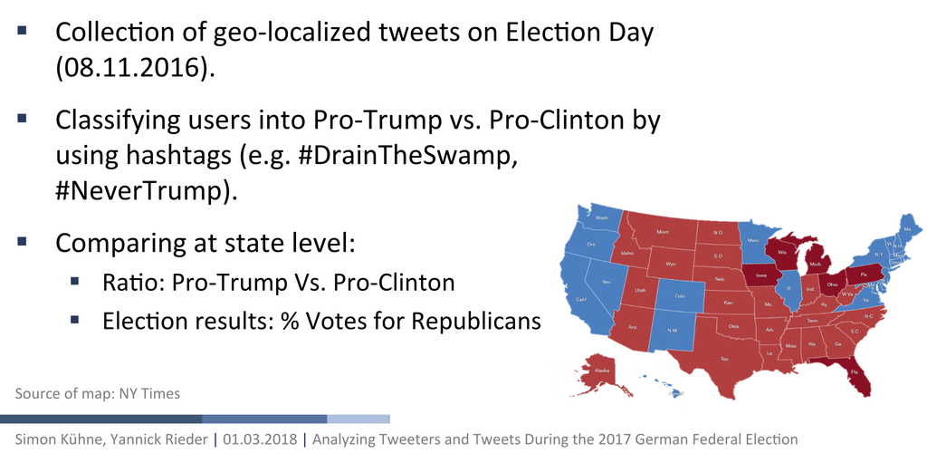

## Example: 2016 U.S. Presidential Election

[figure not shown]

## For more details, see:

Rieder, Y. & S. Kühne, 2018: Geospatial Analysis of Social Media Data - A Practical Framework and Applications. In: Stuetzer, C.M., Welker, M. & M. Egger (Eds.), Computational Social Science in the Age of Big Data. Concepts, Methodologies, Tools, and Applications. DGOF Schriftenreihe, Köln: Herbert van Halem Verlag. http://www.halem-verlag.de/computational-social-science-in-the-age-of-big-data/

## Potential Issues & Challenges

- Bias & 'Representativeness'
- Data Privacy
- Research Ethics
- Data Storage
- Data Access Uncertainty

## Bias & 'Representativeness'

- Twitter is far from representing a random sample of a given population
- Population → Internet Users → Twitter Users → Active Twitter Users → (Users sharing geo-information)
  - Pablo, B. & G. Rivero, 2015: Understanding the Political Representativeness of Twitter Users. Social Science Computer Review 33(6) 712-729.
  - Mellon, J. & C. Prosser, 2017: Twitter and Facebook are not representative of the general population: Political attitudes and demographics of British social media users. Research and Politics 2017: 1-9.
  - Hölig, S., 2018: Eine meinungsstarke Minderheit als Stimmungsbarometer?! Über die Persönlichkeitseigenschaften aktiver Twitterer. M&K Medien- und Kommunikationswissenschaft 66: 140-169.
- Further issues: Social bots, company & institutional accounts

## Replication & Black-Box Twitter

- Real-time Twitter data collection is not reproducible and for a given query you can only hope for Twitter providing you with a true random sample of Tweets
- If completeness is crucial: Pay for access to 100% of all Tweets ever tweeted: *"Both Historical PowerTrack and Full-Archive Search provide access to any publicly available Tweet, starting with the first Tweet from March 2006"* (https://developer.twitter.com/en/docs/tutorials/choosing-historical-api.html)

## Data Privacy

- Twitter's position on data privacy (bluntly): 'Tweets are publicly available, everyone knows that, we see no issues!'
- What about us researchers?
  - DGOF Richtlinien zur Social Media Forschung: http://rat-marktforschung.de/fileadmin/user_upload/pdf/R11_RDMS_D.pdf
  - "In offenen Sozialen Medien bzw. den entsprechenden Bereichen dürfen die personenbezogenen Daten der Teilnehmer grundsätzlich ohne entsprechende explizite Einwilligung auf der Grundlage der gesetzlichen Erlaubnisnorm auch für Zwecke der Markt- und Sozialforschung verarbeitet und genutzt werden."
- DSGVO?
- "Vorratsdatenspeicherung"?
- Twitter's terms of service != German data protection regulations

## Research Ethics

- Further anonymize data? Separate user-ID's from Tweet content and meta-information? Handling Twitter data how we handle survey data?
- Open Science? Share data? Publish user-names? What about celebrities and politicians?

We need an ongoing discussion about these topics!

## Data Access Uncertainty

- Always have in mind that data access is 100% dependent upon Twitter's willingness to share their data
- Also: Potential legal issues and restrictions (#article13 #uploadfilter)
- Facebook's and Instagram's data access was basically shut-down completely within a couple of weeks/months
- Given that, research projects relying on Twitter data are always risky
- In my personal opinion, I would advise against a PhD project that depends on a constant Twitter data influx over a long period of time

## Data Storage

- Data storage can be an issue when Tweets are collected over a long period of time
- Up to 100-200 GB per month
- Storage in a relational database (e.g. SQL) recommended

## Conclusion

- Collecting Twitter data is comparatively easy and cheap
- However, we usually know almost nothing about the users that we collect Tweets from
- Thus, the research potential for social science projects is very limited when we're interested in questions that address 'outside-social-media' phenomena
- In my opinion, we benefit most from Twitter data, when treating it as auxiliary/cheap proxy information and in combination with other data sources
- Potential Applications:
  - Variation in fear of crime across different regions
  - Health monitoring over time
  - Monitoring highly discussed topics in realtime
  - Measuring existing stereotypes towards minorities
  - etc.

## Thank you! - Questions & Discussion

## Contact

Dr. Simon Kühne  
Universität Bielefeld  
AG Methoden der emp. Sozialforschung (Quantitativ)  
Prof. Dr. Martin Kroh  
Universitätsstraße 25  
33615 Bielefeld  
Büro: X-B3-201  
Telefon: 0521 106 4681

[figure not shown]

simon.kuehne@uni-bielefeld.de